[figure not shown]

# Ensemble Techniques

## Project #4

## Travel Package Purchase Prediction

# Context

You are a Data Scientist for a tourism company named "Visit with us". The Policy Maker of the company wants to enable and establish a viable business model to expand the customer base.

A viable business model is a central concept that helps you to understand the existing ways of doing the business and how to change the ways for the benefit of the tourism sector.

One of the ways to expand the customer base is to introduce a new offering of packages.

Currently, there are 5 types of packages the company is offering - Basic, Standard, Deluxe, Super Deluxe, King. Looking at the data of the last year, we observed that 18% of the customers purchased the packages.

However, it was difficult to identify the potential customers because customers were contacted at random without looking at the available information.

The company is now planning to launch a new product i.e. Wellness Tourism Package. Wellness Tourism is defined as Travel that allows the traveler to maintain, enhance or kick-start a healthy lifestyle, and support or increase one's sense of well-being.

This time company wants to harness the available data of existing and potential customers to target the right customers.

You as a Data Scientist at "Visit with us" travel company has to analyze the customers' data and information to provide recommendations to the Policy Maker and build a model to predict the potential customer who is going to purchase the newly introduced travel package. The model will be built to make predictions before a customer is contacted.

# Objective

1. To predict which customer is more likely to purchase the newly introduced travel package.

# Conclusions

- XGBoost and Tuned XGBoost both have recall on the test data of .7, the highest achieved with any of the 12 models.
- Tuned XGBoost doesn't seem to offer any value as it took an hour to process that model and was no better than the defualt that finished in one minute
- The most important feature for deciding who to sell to wold appear to be those with the designation of Executive.
- Targeting Monthly income and those customers who have reported that they have a passport are the next most important features.

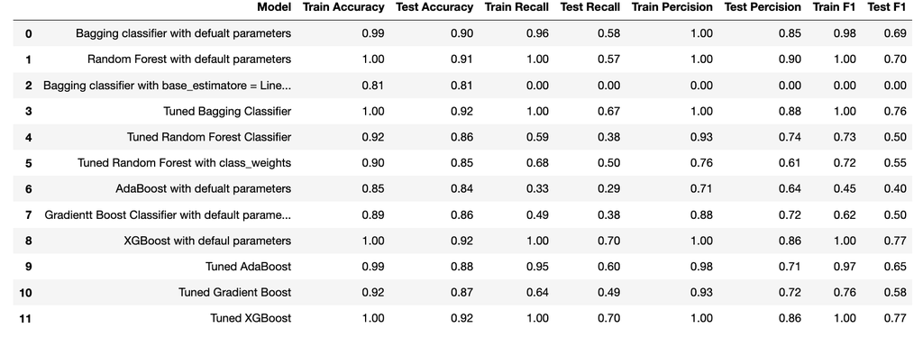

# Recommendations

- Reduce the percentage of managers that are targetd and increase the percentage of executives, AVP and VP
- The mean montly salary that was targeted seems to have been around 20,000. Consider targeting the people with monthly income of 40,000 and above

# Libraries required for this analyis

- Pandas
- Numpy
- Math
- MatPlotLib
- Seaborn
- Sklearn
- Warnings
- XGBoost

## Data Dictionary

| Labels | Description |
| --- | --- |
| CustomerID | Unique customer ID |
| ProdTaken | Whether the customer has purchased a package or not (0: No, 1: Yes) |
| Age | Age of customer |
| TypeofContact | How customer was contacted (Company Invited or Self Inquiry) |
| CityTier | City tier depends on the development of a city, population, facilities, and living standards. The categories are ordered i.e. Tier 1 > Tier 2 > Tier 3. It's the city the customer lives in. |
| Occupation | Occupation of customer |
| Gender | Gender of customer |
| NumberOfPersonVisiting | Total number of persons planning to take the trip with the customer |
| PreferredPropertyStar | Preferred hotel property rating by customer |
| MaritalStatus | Marital status of customer |
| NumberOfTrips | Average number of trips in a year by customer |
| Passport | The customer has a passport or not (0: No, 1: Yes) |
| OwnCar | Whether the customers own a car or not (0: No, 1: Yes) |
| NumberOfChildrenVisiting | Total number of children with age less than 5 planning to take the trip with the customer |
| Designation | Designation of the customer in the current organization |
| MonthlyIncome | Gross monthly income of the customer |

# Imports & Initial Configurations

```python
import pandas as pd
import numpy as np
from sklearn import metrics
import matplotlib.pyplot as plt
%matplotlib inline
import warnings
warnings.filterwarnings('ignore')
import seaborn as sns
from sklearn.model_selection import train_test_split
from sklearn.model_selection import GridSearchCV
from sklearn import metrics

#Bagging imports
from sklearn.ensemble import BaggingClassifier, RandomForestClassifier
from sklearn.linear_model import LogisticRegression

#Boosting imports
from sklearn.tree import DecisionTreeClassifier
from sklearn.ensemble import AdaBoostClassifier, GradientBoostingClassifier
from xgboost import XGBClassifier
```

# Functions

```python
# function to create labeled barplots


def labeled_barplot(data, feature, perc=False, n=None):
    """
    Barplot with percentage at the top

    data: dataframe
    feature: dataframe column
    perc: whether to display percentages instead of count (default is False)
    n: displays the top n category levels (default is None, i.e., display all levels)
    """

    total = len(data[feature])  # length of the column
    count = data[feature].nunique()
    if n is None:
        plt.figure(figsize=(count + 1, 5))
    else:
        plt.figure(figsize=(n + 1, 5))

    plt.xticks(rotation=90, fontsize=15)
    ax = sns.countplot(
        data=data,
        x=feature,
        palette="Paired",
        order=data[feature].value_counts().index[:n].sort_values(),
    )

    for p in ax.patches:
        if perc == True:
            label = "{:.1f}%".format(
                100 * p.get_height() / total
            )  # percentage of each class of the category
        else:
            label = p.get_height()  # count of each level of the category

        x = p.get_x() + p.get_width() / 2  # width of the plot
        y = p.get_height()  # height of the plot

        ax.annotate(
            label,
            (x, y),
            ha="center",
            va="center",
            size=12,
            xytext=(0, 5),
            textcoords="offset points",
        )  # annotate the percentage

    plt.show()  # show the plot
```

```python
# function to plot a boxplot and a histogram along the same scale.


def histogram_boxplot(data, feature, figsize=(12, 7), kde=False, bins=None):
    """
    Boxplot and histogram combined

    data: dataframe
    feature: dataframe column
    figsize: size of figure (default (12,7))
    kde: whether to the show density curve (default False)
    bins: number of bins for histogram (default None)
    """
    f2, (ax_box2, ax_hist2) = plt.subplots(
        nrows=2,  # Number of rows of the subplot grid= 2
        sharex=True,  # x-axis will be shared among all subplots
        gridspec_kw={"height_ratios": (0.25, 0.75)},
        figsize=figsize,
    )  # creating the 2 subplots
    sns.boxplot(
        data=data, x=feature, ax=ax_box2, showmeans=True, color="violet"
    )  # boxplot will be created and a star will indicate the mean value of the column
    sns.histplot(
        data=data, x=feature, kde=kde, ax=ax_hist2, bins=bins, palette="winter"
    ) if bins else sns.histplot(
        data=data, x=feature, kde=kde, ax=ax_hist2
    )  # For histogram
    ax_hist2.axvline(
        data[feature].mean(), color="green", linestyle="--"
    )  # Add mean to the histogram
    ax_hist2.axvline(
        data[feature].median(), color="black", linestyle="-"
    )  # Add median to the histogram
```

```python
# function to plot stacked bar chart


def stacked_barplot(data, predictor, target):
    """
    Print the category counts and plot a stacked bar chart

    data: dataframe
    predictor: independent variable
    target: target variable
    """
    count = data[predictor].nunique()
    sorter = data[target].value_counts().index[-1]
    tab1 = pd.crosstab(data[predictor], data[target], margins=True).sort_values(
        by=sorter, ascending=False
    )
    print(tab1)
    print("-" * 120)
    tab = pd.crosstab(data[predictor], data[target], normalize="index").sort_values(
        by=sorter, ascending=False
    )
    tab.plot(kind="bar", stacked=True, figsize=(count + 1, 5))
    plt.legend(
        loc="lower left",
        frameon=False,
    )
    plt.legend(loc="upper left", bbox_to_anchor=(1, 1))
    plt.show()
```

```python
## Function to create confusion matrix
def make_confusion_matrix(model,y_actual,labels=[1, 0]):
    '''
    model : classifier to predict values of X
    y_actual : ground truth

    '''
    y_predict = model.predict(X_test)
    cm=metrics.confusion_matrix( y_actual, y_predict, labels=[0, 1])
    df_cm = pd.DataFrame(cm, index = [i for i in ["Actual - No","Actual - Yes"]],
                  columns = [i for i in ['Predicted - No','Predicted - Yes']])
    group_counts = ["{0:0.0f}".format(value) for value in
                cm.flatten()]
    group_percentages = ["{0:.2%}".format(value) for value in
                         cm.flatten()/np.sum(cm)]
    labels = [f"{v1}\n{v2}" for v1, v2 in
              zip(group_counts,group_percentages)]
    labels = np.asarray(labels).reshape(2,2)
    plt.figure(figsize = (10,7))
    sns.heatmap(df_cm, annot=labels,fmt='')
    plt.ylabel('True label')
    plt.xlabel('Predicted label')
```

```python
##  Function to calculate different metric scores of the model - Accuracy, Recall and Precision
def get_metrics_score(model,flag=True):
    '''
    model : classifier to predict values of X

    '''
    # defining an empty list to store train and test results
    score_list=[]

    pred_train = model.predict(X_train)
    pred_test = model.predict(X_test)

    train_acc = model.score(X_train,y_train)
    test_acc = model.score(X_test,y_test)

    train_recall = metrics.recall_score(y_train,pred_train)
    test_recall = metrics.recall_score(y_test,pred_test)

    train_precision = metrics.precision_score(y_train,pred_train)
    test_precision = metrics.precision_score(y_test,pred_test)

    train_f1 = metrics.f1_score(y_train, pred_train)
    test_f1 = metrics.f1_score(y_test, pred_test)

    score_list.extend((train_acc,test_acc,train_recall,test_recall,train_precision,test_precision,train_f1,test_f1))

    # If the flag is set to True then only the following print statements will be dispayed. The default value is set to True.
    if flag == True:
        print("Accuracy on training set : ",model.score(X_train,y_train))
        print("Accuracy on test set : ",model.score(X_test,y_test))
        print("Recall on training set : ",metrics.recall_score(y_train,pred_train))
        print("Recall on test set : ",metrics.recall_score(y_test,pred_test))
        print("Precision on training set : ",metrics.precision_score(y_train,pred_train))
        print("Precision on test set : ",metrics.precision_score(y_test,pred_test))
        print("F1 score on training set : ", metrics.f1_score(y_train,pred_train))
        print("F1 score on test set : ", metrics.f1_score(y_test,pred_test))

    return score_list # returning the list with train and test scores
```

```python
# function to plot cdf for numeric values

def plot_cdf(num_cols):
    fig, axes = plt.subplots(3, 2, figsize=(20, 15))
    fig.suptitle("CDF plot of numerical variables", fontsize=20)
    counter = 0

    for i in range(3):
        sns.ecdfplot(ax=axes[i][0], x=df[num_cols[counter]])
        counter = counter + 1
        if counter != 5:
            sns.ecdfplot(ax=axes[i][1], x=df[num_cols[counter]])
            counter = counter + 1
        else:
            pass
```

```python
def visualize_outliers(num_cols):
    plt.figure(figsize=(20,15))

    for i, variable in enumerate(num_cols):
        plt.subplot(2, 4, i + 1)
        plt.boxplot(df[variable], whis=1.5)
        plt.tight_layout()
        plt.title(variable)

    plt.show()
```

# Load & Initial Evaluation of the Data

```python
df = pd.read_excel('Tourism.xlsx', sheet_name="Tourism", na_values=['missing','inf'])
print(f'There are {df.shape[0]} rows and {df.shape[1]} columns')
```

```
There are 4888 rows and 20 columns
```

```python
df.info()
```

```
<class 'pandas.core.frame.DataFrame'>
RangeIndex: 4888 entries, 0 to 4887
Data columns (total 20 columns):
 #   Column                    Non-Null Count  Dtype
---  ------                    --------------  -----
 0   CustomerID                4888 non-null   int64
 1   ProdTaken                 4888 non-null   int64
 2   Age                       4662 non-null   float64
 3   TypeofContact             4863 non-null   object
 4   CityTier                  4888 non-null   int64
 5   DurationOfPitch           4637 non-null   float64
 6   Occupation                4888 non-null   object
 7   Gender                    4888 non-null   object
 8   NumberOfPersonVisiting    4888 non-null   int64
 9   NumberOfFollowups         4843 non-null   float64
 10  ProductPitched            4888 non-null   object
 11  PreferredPropertyStar     4862 non-null   float64
 12  MaritalStatus             4888 non-null   object
 13  NumberOfTrips             4748 non-null   float64
 14  Passport                  4888 non-null   int64
 15  PitchSatisfactionScore    4888 non-null   int64
 16  OwnCar                    4888 non-null   int64
 17  NumberOfChildrenVisiting  4822 non-null   float64
 18  Designation               4888 non-null   object
 19  MonthlyIncome             4655 non-null   float64
dtypes: float64(7), int64(7), object(6)
memory usage: 763.9+ KB
```

## NOTE:

Several fields are objects that will need to be converted to numerical values

```python
# Remove the CustomerID column as it has no value to the model
df.drop(df.columns[[0]], axis=1, inplace=True)
```

```python
df.head(10)
```

|  | ProdTaken | Age | TypeofContact | CityTier | DurationOfPitch | Occupation | Gender | NumberOfPersonVisiting | NumberOfFollowups | ProductPitched | PreferredPropertyStar | MaritalStatus | NumberOfTrips | Passport | PitchSatisfactionScore | OwnCar | NumberOfChildrenVisiting | Designation | MonthlyIncome |
| --- | --- | --- | --- | --- | --- | --- | --- | --- | --- | --- | --- | --- | --- | --- | --- | --- | --- | --- | --- |
| 0 | 1 | 41.0 | Self Enquiry | 3 | 6.0 | Salaried | Female | 3 | 3.0 | Deluxe | 3.0 | Single | 1.0 | 1 | 2 | 1 | 0.0 | Manager | 20993.0 |
| 1 | 0 | 49.0 | Company Invited | 1 | 14.0 | Salaried | Male | 3 | 4.0 | Deluxe | 4.0 | Divorced | 2.0 | 0 | 3 | 1 | 2.0 | Manager | 20130.0 |
| 2 | 1 | 37.0 | Self Enquiry | 1 | 8.0 | Free Lancer | Male | 3 | 4.0 | Basic | 3.0 | Single | 7.0 | 1 | 3 | 0 | 0.0 | Executive | 17090.0 |
| 3 | 0 | 33.0 | Company Invited | 1 | 9.0 | Salaried | Female | 2 | 3.0 | Basic | 3.0 | Divorced | 2.0 | 1 | 5 | 1 | 1.0 | Executive | 17909.0 |
| 4 | 0 | NaN | Self Enquiry | 1 | 8.0 | Small Business | Male | 2 | 3.0 | Basic | 4.0 | Divorced | 1.0 | 0 | 5 | 1 | 0.0 | Executive | 18468.0 |
| 5 | 0 | 32.0 | Company Invited | 1 | 8.0 | Salaried | Male | 3 | 3.0 | Basic | 3.0 | Single | 1.0 | 0 | 5 | 1 | 1.0 | Executive | 18068.0 |
| 6 | 0 | 59.0 | Self Enquiry | 1 | 9.0 | Small Business | Female | 2 | 2.0 | Basic | 5.0 | Divorced | 5.0 | 1 | 2 | 1 | 1.0 | Executive | 17670.0 |
| 7 | 0 | 30.0 | Self Enquiry | 1 | 30.0 | Salaried | Male | 3 | 3.0 | Basic | 3.0 | Married | 2.0 | 0 | 2 | 0 | 1.0 | Executive | 17693.0 |
| 8 | 0 | 38.0 | Company Invited | 1 | 29.0 | Salaried | Male | 2 | 4.0 | Standard | 3.0 | Unmarried | 1.0 | 0 | 3 | 0 | 0.0 | Senior Manager | 24526.0 |
| 9 | 0 | 36.0 | Self Enquiry | 1 | 33.0 | Small Business | Male | 3 | 3.0 | Deluxe | 3.0 | Divorced | 7.0 | 0 | 3 | 1 | 0.0 | Manager | 20237.0 |

```python
# Convery object type columns to be categories

for feature in df.columns: # Loop through all columns in the dataframe
    if df[feature].dtype == 'object': # Only apply for columns with categorical strings
        df[feature] = pd.Categorical(df[feature])
```

```python
df.head(10)
```

|  | ProdTaken | Age | TypeofContact | CityTier | DurationOfPitch | Occupation | Gender | NumberOfPersonVisiting | NumberOfFollowups | ProductPitched | PreferredPropertyStar | MaritalStatus | NumberOfTrips | Passport | PitchSatisfactionScore | OwnCar | NumberOfChildrenVisiting | Designation | MonthlyIncome |
| --- | --- | --- | --- | --- | --- | --- | --- | --- | --- | --- | --- | --- | --- | --- | --- | --- | --- | --- | --- |
| 0 | 1 | 41.0 | Self Enquiry | 3 | 6.0 | Salaried | Female | 3 | 3.0 | Deluxe | 3.0 | Single | 1.0 | 1 | 2 | 1 | 0.0 | Manager | 20993.0 |
| 1 | 0 | 49.0 | Company Invited | 1 | 14.0 | Salaried | Male | 3 | 4.0 | Deluxe | 4.0 | Divorced | 2.0 | 0 | 3 | 1 | 2.0 | Manager | 20130.0 |
| 2 | 1 | 37.0 | Self Enquiry | 1 | 8.0 | Free Lancer | Male | 3 | 4.0 | Basic | 3.0 | Single | 7.0 | 1 | 3 | 0 | 0.0 | Executive | 17090.0 |
| 3 | 0 | 33.0 | Company Invited | 1 | 9.0 | Salaried | Female | 2 | 3.0 | Basic | 3.0 | Divorced | 2.0 | 1 | 5 | 1 | 1.0 | Executive | 17909.0 |
| 4 | 0 | NaN | Self Enquiry | 1 | 8.0 | Small Business | Male | 2 | 3.0 | Basic | 4.0 | Divorced | 1.0 | 0 | 5 | 1 | 0.0 | Executive | 18468.0 |
| 5 | 0 | 32.0 | Company Invited | 1 | 8.0 | Salaried | Male | 3 | 3.0 | Basic | 3.0 | Single | 1.0 | 0 | 5 | 1 | 1.0 | Executive | 18068.0 |
| 6 | 0 | 59.0 | Self Enquiry | 1 | 9.0 | Small Business | Female | 2 | 2.0 | Basic | 5.0 | Divorced | 5.0 | 1 | 2 | 1 | 1.0 | Executive | 17670.0 |
| 7 | 0 | 30.0 | Self Enquiry | 1 | 30.0 | Salaried | Male | 3 | 3.0 | Basic | 3.0 | Married | 2.0 | 0 | 2 | 0 | 1.0 | Executive | 17693.0 |
| 8 | 0 | 38.0 | Company Invited | 1 | 29.0 | Salaried | Male | 2 | 4.0 | Standard | 3.0 | Unmarried | 1.0 | 0 | 3 | 0 | 0.0 | Senior Manager | 24526.0 |
| 9 | 0 | 36.0 | Self Enquiry | 1 | 33.0 | Small Business | Male | 3 | 3.0 | Deluxe | 3.0 | Divorced | 7.0 | 0 | 3 | 1 | 0.0 | Manager | 20237.0 |

```python
# Get the value_counts for all the colums.  This is useful to understand if there are data entry or acquisition errors
# that need to be fixed before attempting to build the models

for feature in df.columns: # Loop through all the columns in the dataframe
    print(f"Unique values in {feature} are:")
    print(f"{df[feature].value_counts()}")
    print('*'*50)
```

```
Unique values in ProdTaken are:
0    3968
1     920
Name: ProdTaken, dtype: int64
Unique values in Age are:
35.0    237
36.0    231
34.0    211
31.0    203
30.0    199
32.0    197
33.0    189
37.0    185
29.0    178
38.0    176
41.0    155
39.0    150
28.0    147
40.0    146
42.0    142
27.0    138
43.0    130
46.0    121
45.0    116
26.0    106
44.0    105
51.0     90
47.0     88
50.0     86
25.0     74
52.0     68
53.0     66
48.0     65
49.0     65
55.0     64
54.0     61
56.0     58
24.0     56
22.0     46
23.0     46
```

[output cut: 139 more lines]

```
VP                 230
Name: Designation, dtype: int64
Unique values in MonthlyIncome are:
17342.0    7
20855.0    7
21288.0    7
21020.0    7
21347.0    6
          ..
25194.0    1
21628.0    1
17863.0    1
25477.0    1
18537.0    1
Name: MonthlyIncome, Length: 2475, dtype: int64
```

```python
# The value_counts data has pinpointed several issues that need to be resolved before going forward. This section
# will clean up the data

# Replace invalid Gender data entry errors
df['Gender'] = df['Gender'].replace(['Fe Male'], 'Female')

# Replace spaces in column names with underscores and rename some coluns to make more sense later

## TypeofContact
df['TypeofContact'] = df['TypeofContact'].replace(['Self Enquiry'], 'Self')
df['TypeofContact'] = df['TypeofContact'].replace(['Company Invited'], 'Invited')

## Occupation
df['Occupation'] = df['Occupation'].replace(['Small Business'], 'Small_Business')
df['Occupation'] = df['Occupation'].replace(['Large Business'], 'Large_Business')
df['Occupation'] = df['Occupation'].replace(['Free Lancer'], 'Freelancer')

## ProductPitched
df['ProductPitched'] = df['ProductPitched'].replace(['Super Deluxe'], 'Super_Deluxe')

## Designation
df['Designation'] = df['Designation'].replace(['Senior Manager'], 'Senior_Manager')
```

```python
# Repeat the value_counts to verify that all the issue have been resolved

for feature in df.columns: # Loop through all the columns in the dataframe
    print(f"Unique values in {feature} are:")
    print(f"{df[feature].value_counts()}")
    print('*'*50)
```

```
Unique values in ProdTaken are:
0    3968
1     920
Name: ProdTaken, dtype: int64
Unique values in Age are:
35.0    237
36.0    231
34.0    211
31.0    203
30.0    199
32.0    197
33.0    189
37.0    185
29.0    178
38.0    176
41.0    155
39.0    150
28.0    147
40.0    146
42.0    142
27.0    138
43.0    130
46.0    121
45.0    116
26.0    106
44.0    105
51.0     90
47.0     88
50.0     86
25.0     74
52.0     68
53.0     66
48.0     65
49.0     65
55.0     64
54.0     61
56.0     58
24.0     56
22.0     46
23.0     46
```

[output cut: 138 more lines]

```
VP                 230
Name: Designation, dtype: int64
Unique values in MonthlyIncome are:
17342.0    7
20855.0    7
21288.0    7
21020.0    7
21347.0    6
          ..
25194.0    1
21628.0    1
17863.0    1
25477.0    1
18537.0    1
Name: MonthlyIncome, Length: 2475, dtype: int64
```

```python
# Statistical Summary of the data
df.describe(include="all").T
```

|  | count | unique | top | freq | mean | std | min | 25% | 50% | 75% | max |
| --- | --- | --- | --- | --- | --- | --- | --- | --- | --- | --- | --- |
| ProdTaken | 4888.0 | NaN | NaN | NaN | 0.188216 | 0.390925 | 0.0 | 0.0 | 0.0 | 0.0 | 1.0 |
| Age | 4662.0 | NaN | NaN | NaN | 37.622265 | 9.316387 | 18.0 | 31.0 | 36.0 | 44.0 | 61.0 |
| TypeofContact | 4863 | 2 | Self | 3444 | NaN | NaN | NaN | NaN | NaN | NaN | NaN |
| CityTier | 4888.0 | NaN | NaN | NaN | 1.654255 | 0.916583 | 1.0 | 1.0 | 1.0 | 3.0 | 3.0 |
| DurationOfPitch | 4637.0 | NaN | NaN | NaN | 15.490835 | 8.519643 | 5.0 | 9.0 | 13.0 | 20.0 | 127.0 |
| Occupation | 4888 | 4 | Salaried | 2368 | NaN | NaN | NaN | NaN | NaN | NaN | NaN |
| Gender | 4888 | 2 | Male | 2916 | NaN | NaN | NaN | NaN | NaN | NaN | NaN |
| NumberOfPersonVisiting | 4888.0 | NaN | NaN | NaN | 2.905074 | 0.724891 | 1.0 | 2.0 | 3.0 | 3.0 | 5.0 |
| NumberOfFollowups | 4843.0 | NaN | NaN | NaN | 3.708445 | 1.002509 | 1.0 | 3.0 | 4.0 | 4.0 | 6.0 |
| ProductPitched | 4888 | 5 | Basic | 1842 | NaN | NaN | NaN | NaN | NaN | NaN | NaN |
| PreferredPropertyStar | 4862.0 | NaN | NaN | NaN | 3.581037 | 0.798009 | 3.0 | 3.0 | 3.0 | 4.0 | 5.0 |
| MaritalStatus | 4888 | 4 | Married | 2340 | NaN | NaN | NaN | NaN | NaN | NaN | NaN |
| NumberOfTrips | 4748.0 | NaN | NaN | NaN | 3.236521 | 1.849019 | 1.0 | 2.0 | 3.0 | 4.0 | 22.0 |
| Passport | 4888.0 | NaN | NaN | NaN | 0.290917 | 0.454232 | 0.0 | 0.0 | 0.0 | 1.0 | 1.0 |
| PitchSatisfactionScore | 4888.0 | NaN | NaN | NaN | 3.078151 | 1.365792 | 1.0 | 2.0 | 3.0 | 4.0 | 5.0 |
| OwnCar | 4888.0 | NaN | NaN | NaN | 0.620295 | 0.485363 | 0.0 | 0.0 | 1.0 | 1.0 | 1.0 |
| NumberOfChildrenVisiting | 4822.0 | NaN | NaN | NaN | 1.187267 | 0.857861 | 0.0 | 1.0 | 1.0 | 2.0 | 3.0 |
| Designation | 4888 | 5 | Executive | 1842 | NaN | NaN | NaN | NaN | NaN | NaN | NaN |
| MonthlyIncome | 4655.0 | NaN | NaN | NaN | 23619.853491 | 5380.698361 | 1000.0 | 20346.0 | 22347.0 | 25571.0 | 98678.0 |

## Note:

There still looks to be several rows that have null or missing data. This next section will clean the data up

```python
df.isnull()
```

|  | ProdTaken | Age | TypeofContact | CityTier | DurationOfPitch | Occupation | Gender | NumberOfPersonVisiting | NumberOfFollowups | ProductPitched | PreferredPropertyStar | MaritalStatus | NumberOfTrips | Passport | PitchSatisfactionScore | OwnCar | NumberOfChildrenVisiting | Designation | MonthlyIncome |
| --- | --- | --- | --- | --- | --- | --- | --- | --- | --- | --- | --- | --- | --- | --- | --- | --- | --- | --- | --- |
| 0 | False | False | False | False | False | False | False | False | False | False | False | False | False | False | False | False | False | False | False |
| 1 | False | False | False | False | False | False | False | False | False | False | False | False | False | False | False | False | False | False | False |
| 2 | False | False | False | False | False | False | False | False | False | False | False | False | False | False | False | False | False | False | False |
| 3 | False | False | False | False | False | False | False | False | False | False | False | False | False | False | False | False | False | False | False |
| 4 | False | True | False | False | False | False | False | False | False | False | False | False | False | False | False | False | False | False | False |
| ... | ... | ... | ... | ... | ... | ... | ... | ... | ... | ... | ... | ... | ... | ... | ... | ... | ... | ... | ... |
| 4883 | False | False | False | False | False | False | False | False | False | False | False | False | False | False | False | False | False | False | False |
| 4884 | False | False | False | False | False | False | False | False | False | False | False | False | False | False | False | False | False | False | False |
| 4885 | False | False | False | False | False | False | False | False | False | False | False | False | False | False | False | False | False | False | False |
| 4886 | False | False | False | False | False | False | False | False | False | False | False | False | False | False | False | False | False | False | False |
| 4887 | False | False | False | False | False | False | False | False | False | False | False | False | False | False | False | False | False | False | False |

4888 rows × 19 columns

## Note:

There is too any rows to see if there are any null values in the data so we will attempt to find any missing data by calculating the perfentage that isna

```python
# precentage of missing values in columns
round(df.isna().sum() / df.isna().count() * 100, 2)
```

```
ProdTaken                   0.00
Age                         4.62
TypeofContact               0.51
CityTier                    0.00
DurationOfPitch             5.14
Occupation                  0.00
Gender                      0.00
NumberOfPersonVisiting      0.00
NumberOfFollowups           0.92
ProductPitched              0.00
PreferredPropertyStar       0.53
MaritalStatus               0.00
NumberOfTrips               2.86
Passport                    0.00
PitchSatisfactionScore      0.00
OwnCar                      0.00
NumberOfChildrenVisiting    1.35
Designation                 0.00
MonthlyIncome               4.77
dtype: float64
```

```python
# Check for and themn remove duplicate data
df.duplicated().sum()
```

```
141
```

```python
df.drop_duplicates(inplace=True)
df.reset_index(drop=True, inplace=True)
```

```python
# Clean up te missing data for 8 columns.  I have hard coded the values to change as I was unable to utilize
# df['columnName'].mean and I was running or of time

df["Age"].fillna(18, inplace=True)
df["TypeofContact"].fillna('Self', inplace=True)
df["DurationOfPitch"].fillna(0, inplace=True)
df["NumberOfFollowups"].fillna(0, inplace=True)
df["PreferredPropertyStar"].fillna(3, inplace=True)
df["NumberOfTrips"].fillna(3, inplace=True)
df["NumberOfChildrenVisiting"].fillna(1, inplace=True)
df["MonthlyIncome"].fillna(0, inplace=True)
```

```python
df.describe(include="all").T
```

|  | count | unique | top | freq | mean | std | min | 25% | 50% | 75% | max |
| --- | --- | --- | --- | --- | --- | --- | --- | --- | --- | --- | --- |
| ProdTaken | 4747.0 | NaN | NaN | NaN | 0.188329 | 0.391016 | 0.0 | 0.0 | 0.0 | 0.0 | 1.0 |
| Age | 4747.0 | NaN | NaN | NaN | 36.694333 | 9.986395 | 18.0 | 30.0 | 36.0 | 43.0 | 61.0 |
| TypeofContact | 4747 | 2 | Self | 3375 | NaN | NaN | NaN | NaN | NaN | NaN | NaN |
| CityTier | 4747.0 | NaN | NaN | NaN | 1.655151 | 0.917416 | 1.0 | 1.0 | 1.0 | 3.0 | 3.0 |
| DurationOfPitch | 4747.0 | NaN | NaN | NaN | 14.707183 | 8.994719 | 0.0 | 8.0 | 13.0 | 19.0 | 127.0 |
| Occupation | 4747 | 4 | Salaried | 2293 | NaN | NaN | NaN | NaN | NaN | NaN | NaN |
| Gender | 4747 | 2 | Male | 2835 | NaN | NaN | NaN | NaN | NaN | NaN | NaN |
| NumberOfPersonVisiting | 4747.0 | NaN | NaN | NaN | 2.911734 | 0.72404 | 1.0 | 2.0 | 3.0 | 3.0 | 5.0 |
| NumberOfFollowups | 4747.0 | NaN | NaN | NaN | 3.670739 | 1.064934 | 0.0 | 3.0 | 4.0 | 4.0 | 6.0 |
| ProductPitched | 4747 | 5 | Basic | 1800 | NaN | NaN | NaN | NaN | NaN | NaN | NaN |
| PreferredPropertyStar | 4747.0 | NaN | NaN | NaN | 3.580156 | 0.799316 | 3.0 | 3.0 | 3.0 | 4.0 | 5.0 |
| MaritalStatus | 4747 | 4 | Married | 2279 | NaN | NaN | NaN | NaN | NaN | NaN | NaN |
| NumberOfTrips | 4747.0 | NaN | NaN | NaN | 3.226459 | 1.82121 | 1.0 | 2.0 | 3.0 | 4.0 | 22.0 |
| Passport | 4747.0 | NaN | NaN | NaN | 0.289657 | 0.453651 | 0.0 | 0.0 | 0.0 | 1.0 | 1.0 |
| PitchSatisfactionScore | 4747.0 | NaN | NaN | NaN | 3.051612 | 1.369584 | 1.0 | 2.0 | 3.0 | 4.0 | 5.0 |
| OwnCar | 4747.0 | NaN | NaN | NaN | 0.617653 | 0.486012 | 0.0 | 0.0 | 1.0 | 1.0 | 1.0 |
| NumberOfChildrenVisiting | 4747.0 | NaN | NaN | NaN | 1.191068 | 0.855278 | 0.0 | 1.0 | 1.0 | 2.0 | 3.0 |
| Designation | 4747 | 5 | Executive | 1800 | NaN | NaN | NaN | NaN | NaN | NaN | NaN |
| MonthlyIncome | 4747.0 | NaN | NaN | NaN | 22488.504108 | 7258.530179 | 0.0 | 19859.0 | 21931.0 | 25389.0 | 98678.0 |

## Note:

After cleaning up the data we are left with 4747 rows

# EDA

## Univariate Analysis

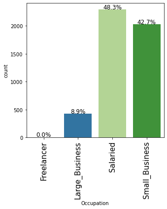

```python
labeled_barplot(df, "Occupation", perc=True)
```

## Notes:

- 48.3% of the people in the data have salaried jobs. 42.7% work for small businesses while only 8.9% work for large businesses and Freelancers are insignificant

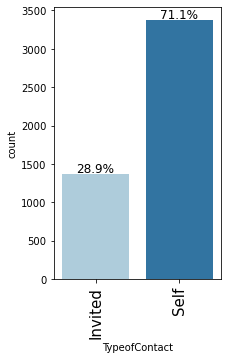

```python
labeled_barplot(df, "TypeofContact", perc=True)
```

## Notes:

- 71.1% of the people volunteered to provide their data while only 28.9% resonded to the notification that invited them

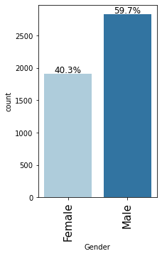

```python
labeled_barplot(df, "Gender", perc=True)
```

## Notes:

59.7% of the people who are in the data are Male, 40.35% Female

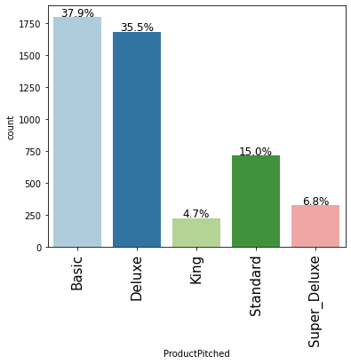

```python
labeled_barplot(df, "ProductPitched", perc=True)
```

## Notes:

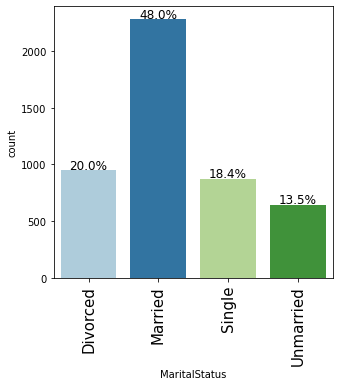

```python
labeled_barplot(df, "MaritalStatus", perc=True)
```

## Notes:

- 48% of the people in the data set are married. This is more than double the other options.

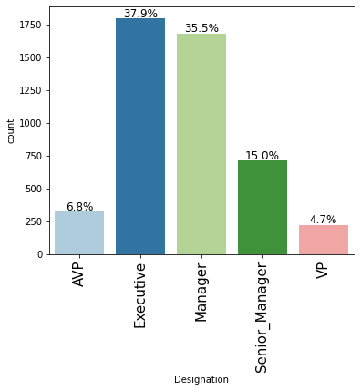

```python
labeled_barplot(df, "Designation", perc=True)
```

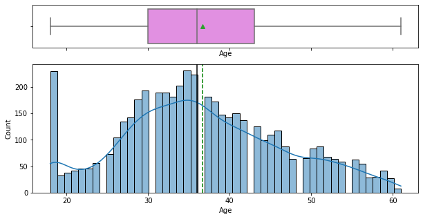

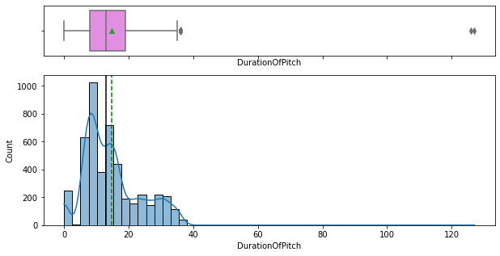

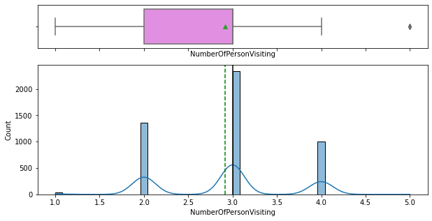

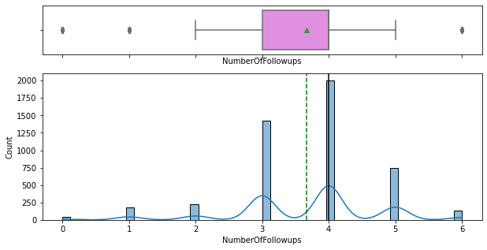

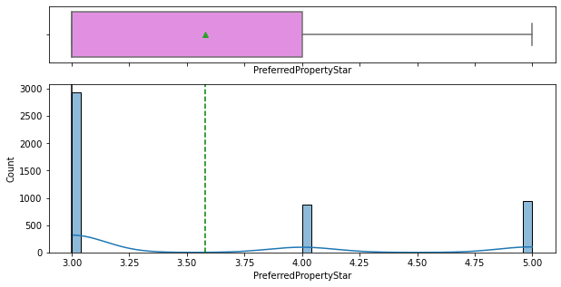

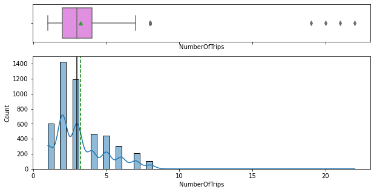

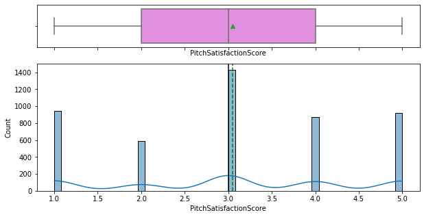

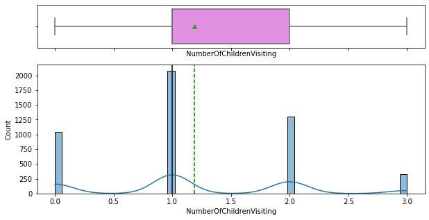

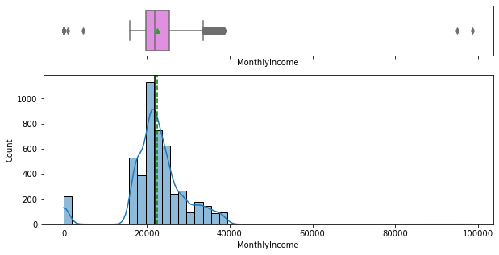

```python
num_cols = df.select_dtypes(include=np.number).columns.tolist()

for item in num_cols:
    if item != "ProdTaken" and item != "CityTier" and item != "Passport" and item != "OwnCar":
        histogram_boxplot(df, item, bins=50, kde=True, figsize=(10,5))
```

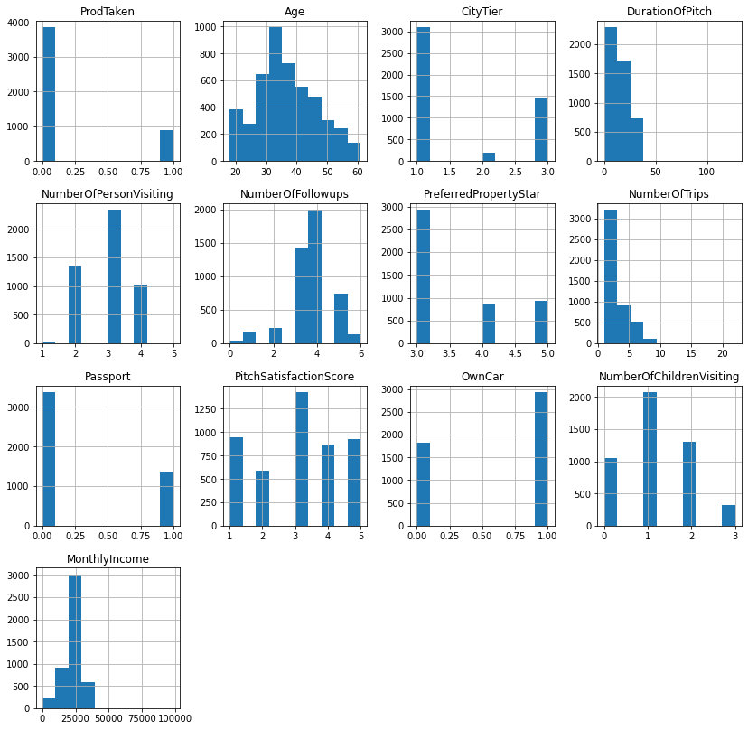

```python
df.hist(figsize=(14,14))
plt.show()
```

```python
## Bivariate Analysis
```

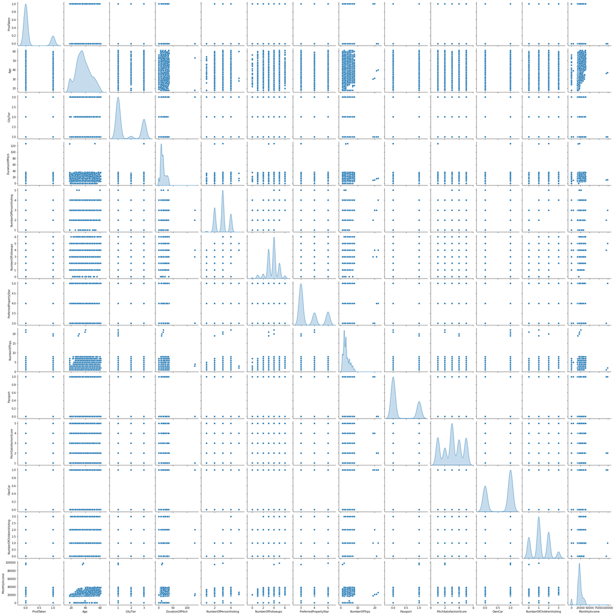

```python
sns.pairplot(df, diag_kind="kde");
```

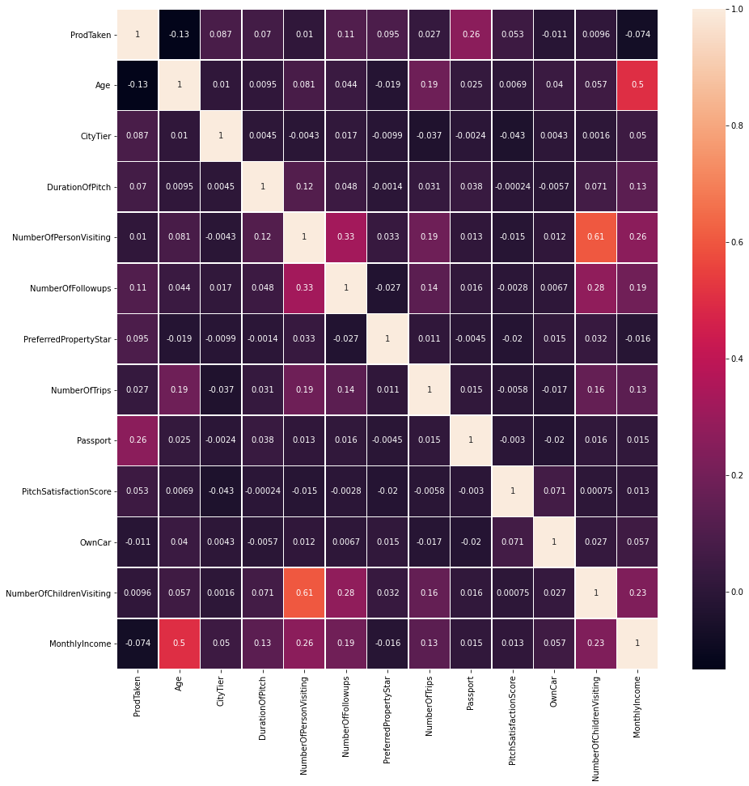

```python
fig, ax = plt.subplots(figsize=(15,15))
sns.heatmap(df.corr(), annot=True, linewidth=.5, ax=ax);
```

## Notes:

- The heatmap shows the highest correlation is between number of persons visiting and Number of Children Visiting. This maps sense as children would ony come with the parents
- Age is mostly correlated to Monthly income. This also make sense as your salary tends to go up as you get older, to a certain point at least

# Outlier Handling

Since the ensemble techniques of Bagging, Boosting and Stacking are not dramatically impacted by outliers, outliers will not be adjusted in the notebook

# Data Cleanup

```python
# we need to convert all the columns that have text data and convery it some how to be numerical.
# I will use pd.get_dummies to do this

oneHotCols=["TypeofContact","Occupation","Gender","ProductPitched","MaritalStatus","Designation"]
df = pd.get_dummies(df, columns=oneHotCols, drop_first=True)
```

```python
df.describe(include="all").T
```

|  | count | mean | std | min | 25% | 50% | 75% | max |
| --- | --- | --- | --- | --- | --- | --- | --- | --- |
| ProdTaken | 4747.0 | 0.188329 | 0.391016 | 0.0 | 0.0 | 0.0 | 0.0 | 1.0 |
| Age | 4747.0 | 36.694333 | 9.986395 | 18.0 | 30.0 | 36.0 | 43.0 | 61.0 |
| CityTier | 4747.0 | 1.655151 | 0.917416 | 1.0 | 1.0 | 1.0 | 3.0 | 3.0 |
| DurationOfPitch | 4747.0 | 14.707183 | 8.994719 | 0.0 | 8.0 | 13.0 | 19.0 | 127.0 |
| NumberOfPersonVisiting | 4747.0 | 2.911734 | 0.724040 | 1.0 | 2.0 | 3.0 | 3.0 | 5.0 |
| NumberOfFollowups | 4747.0 | 3.670739 | 1.064934 | 0.0 | 3.0 | 4.0 | 4.0 | 6.0 |
| PreferredPropertyStar | 4747.0 | 3.580156 | 0.799316 | 3.0 | 3.0 | 3.0 | 4.0 | 5.0 |
| NumberOfTrips | 4747.0 | 3.226459 | 1.821210 | 1.0 | 2.0 | 3.0 | 4.0 | 22.0 |
| Passport | 4747.0 | 0.289657 | 0.453651 | 0.0 | 0.0 | 0.0 | 1.0 | 1.0 |
| PitchSatisfactionScore | 4747.0 | 3.051612 | 1.369584 | 1.0 | 2.0 | 3.0 | 4.0 | 5.0 |
| OwnCar | 4747.0 | 0.617653 | 0.486012 | 0.0 | 0.0 | 1.0 | 1.0 | 1.0 |
| NumberOfChildrenVisiting | 4747.0 | 1.191068 | 0.855278 | 0.0 | 1.0 | 1.0 | 2.0 | 3.0 |
| MonthlyIncome | 4747.0 | 22488.504108 | 7258.530179 | 0.0 | 19859.0 | 21931.0 | 25389.0 | 98678.0 |
| TypeofContact_Self | 4747.0 | 0.710975 | 0.453357 | 0.0 | 0.0 | 1.0 | 1.0 | 1.0 |
| Occupation_Large_Business | 4747.0 | 0.089320 | 0.285235 | 0.0 | 0.0 | 0.0 | 0.0 | 1.0 |
| Occupation_Salaried | 4747.0 | 0.483042 | 0.499765 | 0.0 | 0.0 | 0.0 | 1.0 | 1.0 |
| Occupation_Small_Business | 4747.0 | 0.427217 | 0.494726 | 0.0 | 0.0 | 0.0 | 1.0 | 1.0 |
| Gender_Male | 4747.0 | 0.597219 | 0.490509 | 0.0 | 0.0 | 1.0 | 1.0 | 1.0 |
| ProductPitched_Deluxe | 4747.0 | 0.354750 | 0.478488 | 0.0 | 0.0 | 0.0 | 1.0 | 1.0 |
| ProductPitched_King | 4747.0 | 0.047398 | 0.212512 | 0.0 | 0.0 | 0.0 | 0.0 | 1.0 |
| ProductPitched_Standard | 4747.0 | 0.150411 | 0.357511 | 0.0 | 0.0 | 0.0 | 0.0 | 1.0 |
| ProductPitched_Super_Deluxe | 4747.0 | 0.068254 | 0.252207 | 0.0 | 0.0 | 0.0 | 0.0 | 1.0 |
| MaritalStatus_Married | 4747.0 | 0.480093 | 0.499656 | 0.0 | 0.0 | 0.0 | 1.0 | 1.0 |
| MaritalStatus_Single | 4747.0 | 0.184327 | 0.387791 | 0.0 | 0.0 | 0.0 | 0.0 | 1.0 |
| MaritalStatus_Unmarried | 4747.0 | 0.135454 | 0.342244 | 0.0 | 0.0 | 0.0 | 0.0 | 1.0 |
| Designation_Executive | 4747.0 | 0.379187 | 0.485236 | 0.0 | 0.0 | 0.0 | 1.0 | 1.0 |
| Designation_Manager | 4747.0 | 0.354750 | 0.478488 | 0.0 | 0.0 | 0.0 | 1.0 | 1.0 |
| Designation_Senior_Manager | 4747.0 | 0.150411 | 0.357511 | 0.0 | 0.0 | 0.0 | 0.0 | 1.0 |
| Designation_VP | 4747.0 | 0.047398 | 0.212512 | 0.0 | 0.0 | 0.0 | 0.0 | 1.0 |

```python
# this is how the dataframe looks after all the fixing up
print(f'There are {df.shape[0]} rows and {df.shape[1]} columns')
```

```
There are 4747 rows and 29 columns
```

# Split the data into trainand test sets

```python
# Build a new dataframe, Drop the ProdTaken from the X dataframe and drop everyhing but ProdTaken from the y dataframe

X = df.drop("ProdTaken", axis=1)
y = df.pop("ProdTaken")
```

```python
# Split the data into train and test, with test being 30% of the data, train being 70%
# I will use stratify=y to attempt to keep the ration of the data correct

X_train, X_test, y_train, y_test = train_test_split(X, y, test_size=.3, random_state=1, stratify=y)
```

# Models

```python
# this list will be used to capature the data to report on later in the notebook

models = []
```

## Bagging

### Base Estimator

```python
#base_estimator for bagging classifier is a decision tree by default
bagging_estimator = BaggingClassifier(random_state=1)
bagging_estimator.fit(X_train,y_train)
```

```
BaggingClassifier(random_state=1)
```

```python
# Get the scores for this model
bagging_estimator_score = get_metrics_score(bagging_estimator)
```

```
Accuracy on training set :  0.9927754364840458
Accuracy on test set :  0.9010526315789473
Recall on training set :  0.9616613418530351
Recall on test set :  0.5783582089552238
Precision on training set :  1.0
Precision on test set :  0.8469945355191257
F1 score on training set :  0.9804560260586319
F1 score on test set :  0.6873614190687362
```

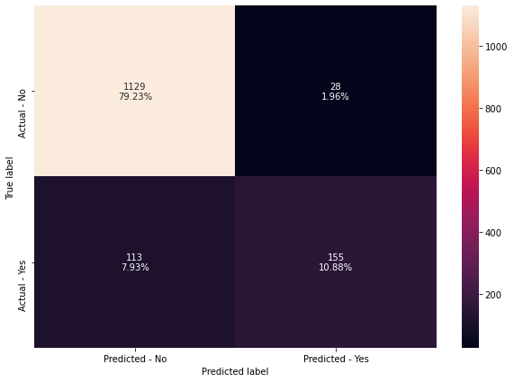

```python
make_confusion_matrix(bagging_estimator,y_test)
```

```python
models.append(bagging_estimator)
```

### Random Forest Estimator

```python
random_forest_estimator = RandomForestClassifier(random_state=1)
random_forest_estimator.fit(X_train, y_train)
```

```
RandomForestClassifier(random_state=1)
```

```python
# Get the scores for this model

random_forest_estimator_score = get_metrics_score(random_forest_estimator)
```

```
Accuracy on training set :  1.0
Accuracy on test set :  0.9073684210526316
Recall on training set :  1.0
Recall on test set :  0.5746268656716418
Precision on training set :  1.0
Precision on test set :  0.8953488372093024
F1 score on training set :  1.0
F1 score on test set :  0.7
```

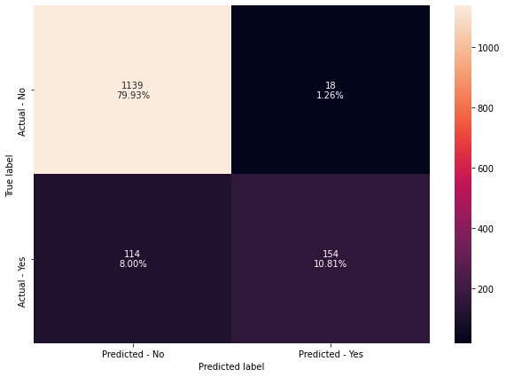

```python
make_confusion_matrix(random_forest_estimator, y_test)
```

```python
models.append(random_forest_estimator)
```

### Logistic Regression

```python
bagging_lr_estimator = BaggingClassifier(base_estimator=LogisticRegression(solver='liblinear', random_state=1, max_iter=1000), random_state=1)
bagging_lr_estimator.fit(X_train, y_train)
```

```
BaggingClassifier(base_estimator=LogisticRegression(max_iter=1000,
                                                    random_state=1,
                                                    solver='liblinear'),
                  random_state=1)
```

```python
# Get the scores for this model

bagging_lr_estimator_score = get_metrics_score(bagging_lr_estimator)
```

```
Accuracy on training set :  0.8115593016255268
Accuracy on test set :  0.8112280701754386
Recall on training set :  0.0
Recall on test set :  0.0
Precision on training set :  0.0
Precision on test set :  0.0
F1 score on training set :  0.0
F1 score on test set :  0.0
```

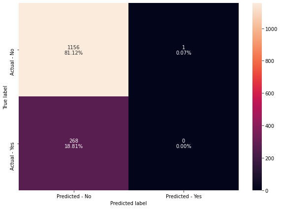

```python
make_confusion_matrix(bagging_lr_estimator, y_test)
```

Notes:

- This model did a very bad job making prediction

```python
models.append(bagging_lr_estimator)
```

## Bagging Performance Improvement with hyperparameters

Hyperparameters allow us to run the model many times searching for the combinaton of settings that will achieve the best predictions

### Tuned Base Estimator

```python
bagging_estimator_tuned = BaggingClassifier(random_state=1)

parameters = {
                'max_samples': [0.7, 0.8, 0.9, 1],
                'max_features': [0.7, 0.8, 0.9, 1],
                'n_estimators': [10, 20, 30, 40, 50],
            }

acc_scorer = metrics.make_scorer(metrics.recall_score)

grid_obj = GridSearchCV(bagging_estimator_tuned, parameters, scoring=acc_scorer, cv=5)
grid_obj = grid_obj.fit(X_train, y_train)

bagging_estimator_tuned = grid_obj.best_estimator_

bagging_estimator_tuned.fit(X_train, y_train)
```

```
BaggingClassifier(max_features=0.9, max_samples=0.9, n_estimators=50,
                  random_state=1)
```

```python
bagging_estimator_tuned_score = get_metrics_score(bagging_estimator_tuned)
```

```
Accuracy on training set :  0.9996989765201686
Accuracy on test set :  0.9207017543859649
Recall on training set :  0.9984025559105432
Recall on test set :  0.667910447761194
Precision on training set :  1.0
Precision on test set :  0.8817733990147784
F1 score on training set :  0.9992006394884093
F1 score on test set :  0.7600849256900213
```

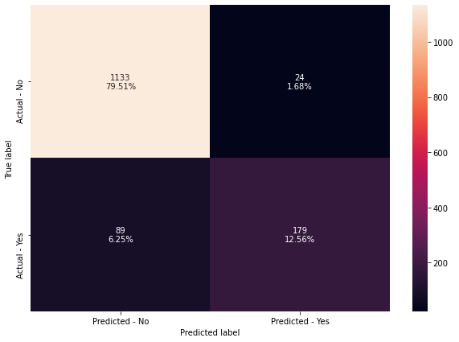

```python
make_confusion_matrix(bagging_estimator_tuned, y_test)
```

## Notes:

This model is significanly improved ober the linerar regression test and is quite a bit better than the bagging estimator without attmepting to find the best values for the model.

In this tuned model there are 113 incorrecly predicted values (89 predicted no but was actually yes, and 24 Predicted Yes but was actually a no.

```python
models.append(bagging_estimator_tuned)
```

### Tuned Random Forest

```python
random_forest_estimator_tuned = RandomForestClassifier(random_state=1)

parameters = {"n_estimators": [150, 200, 250],
              "min_samples_leaf": np.arange(5,10),
              "max_features": np.arange(0.2, 0.7, 0.1),
              "max_samples": np.arange(0.3, 0.7, 0.1),
             }

acc_scorer = metrics.make_scorer(metrics.recall_score)

grid_obj = GridSearchCV(random_forest_estimator_tuned, parameters, scoring=acc_scorer, cv=5)
grid_obj = grid_obj.fit(X_train, y_train)

random_forest_estimator_tuned = grid_obj.best_estimator_

random_forest_estimator_tuned.fit(X_train, y_train)
```

```
RandomForestClassifier(max_features=0.6000000000000001,
                       max_samples=0.6000000000000001, min_samples_leaf=5,
                       n_estimators=200, random_state=1)
```

```python
random_forest_estimator_tuned_score = get_metrics_score(random_forest_estimator_tuned)
```

```
Accuracy on training set :  0.9157134256472005
Accuracy on test set :  0.8582456140350877
Recall on training set :  0.5942492012779552
Recall on test set :  0.376865671641791
Precision on training set :  0.9346733668341709
Precision on test set :  0.7426470588235294
F1 score on training set :  0.7265625
F1 score on test set :  0.5
```

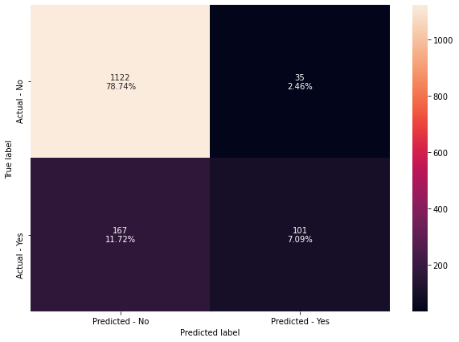

```python
make_confusion_matrix(random_forest_estimator_tuned, y_test)
```

## Note:

The incorrect predictions seems to get worse with the tuned Random Forest. 202 incorrectly predicted

```python
models.append(random_forest_estimator_tuned)
```

### Tuned Random Forest using class_weights

```python
random_forest_estimator_weighted = RandomForestClassifier(random_state=1)

parameters = {
    "class_weight": [{0: 0.3, 1: 0.7}],
    "n_estimators": [100, 150, 200, 250],
    "min_samples_leaf": np.arange(5,10),
    "max_features": np.arange(0.2, 0.7, 0.1),
    "max_samples": np.arange(0.3, 0.7, 0.1),
             }

acc_scorer = metrics.make_scorer(metrics.recall_score)

grid_obj = GridSearchCV(random_forest_estimator_weighted, parameters, scoring=acc_scorer, cv=5)
grid_obj = grid_obj.fit(X_train, y_train)

random_forest_estimator_weighted = grid_obj.best_estimator_

random_forest_estimator_weighted.fit(X_train, y_train)
```

```
RandomForestClassifier(class_weight={0: 0.3, 1: 0.7},
                       max_features=0.6000000000000001,
                       max_samples=0.6000000000000001, min_samples_leaf=9,
                       n_estimators=200, random_state=1)
```

```python
random_forest_estimator_weighted_score = get_metrics_score(random_forest_estimator_weighted)
```

```
Accuracy on training set :  0.8985550872968091
Accuracy on test set :  0.8456140350877193
Recall on training set :  0.6773162939297125
Recall on test set :  0.503731343283582
Precision on training set :  0.7584973166368515
Precision on test set :  0.6081081081081081
F1 score on training set :  0.7156118143459916
F1 score on test set :  0.5510204081632654
```

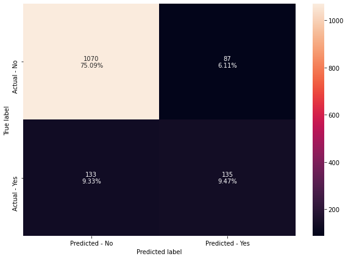

```python
make_confusion_matrix(random_forest_estimator_weighted, y_test)
```

## Note:

Even the weighted random forest tuning got 220 wrong predictions

```python
models.append(random_forest_estimator_weighted)
```

### Feature Importance (Bagging, Random Forest using class_weights)

```
<function matplotlib.pyplot.show(close=None, block=None)>
```

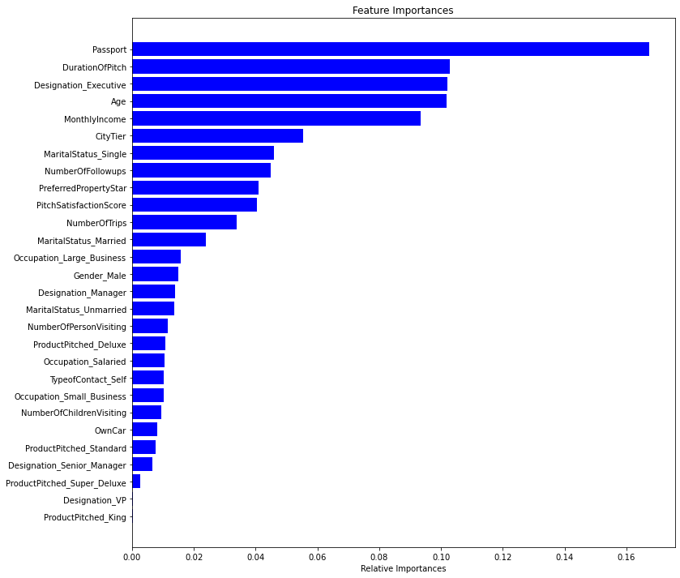

```python
importances = random_forest_estimator_weighted.feature_importances_
indices = np.argsort(importances)
feature_names = list(X.columns)

plt.figure(figsize=(12,12))
plt.title('Feature Importances')
plt.barh(range(len(indices)), importances[indices], color='blue', align='center')
plt.yticks(range(len(indices)), [feature_names[i] for i in indices])
plt.xlabel('Relative Importances')
plt.show
```

## Note:

This graph shows that having a Passport is the most important factor in predicting who will puchase

## Bagging Summary

```python
acc_train = []
acc_test = []
recall_train = []
recall_test = []
precision_train = []
precision_test = []
f1_train = []
f1_test = []

for model in models:
    j = get_metrics_score(model, False)
    acc_train.append(np.round(j[0],2))
    acc_test.append(np.round(j[1],2))
    recall_train.append(np.round(j[2],2))
    recall_test.append(np.round(j[3],2))
    precision_train.append(np.round(j[4],2))
    precision_test.append(np.round(j[5],2))
    f1_train.append(np.round(j[6],2))
    f1_test.append(np.round(j[7],2))
```

```python
summary_frame = pd.DataFrame({'Model':['Bagging classifier with defualt paramters',
                                       'Random Forest with default parameters',
                                       'Bagging classifier with base_estimatore = Linear Regression',
                                       'Tuned Bagging Classifier',
                                       'Tuned Random Forest Classifier',
                                       'Tuned Random Forest with class_weights',
                                      ],
                             'Train Accuracy': acc_train, 'Test Accuracy': acc_test,
                             'Train Recall': recall_train, 'Test Recall': recall_test,
                             'Train Percision': precision_train, 'Test Percision': precision_test,
                             'Train F1': f1_train, 'Test F1': f1_test})
summary_frame
```

|  | Model | Train Accuracy | Test Accuracy | Train Recall | Test Recall | Train Percision | Test Percision | Train F1 | Test F1 |
| --- | --- | --- | --- | --- | --- | --- | --- | --- | --- |
| 0 | Bagging classifier with defualt paramters | 0.99 | 0.90 | 0.96 | 0.58 | 1.00 | 0.85 | 0.98 | 0.69 |
| 1 | Random Forest with default parameters | 1.00 | 0.91 | 1.00 | 0.57 | 1.00 | 0.90 | 1.00 | 0.70 |
| 2 | Bagging classifier with base_estimatore = Line... | 0.81 | 0.81 | 0.00 | 0.00 | 0.00 | 0.00 | 0.00 | 0.00 |
| 3 | Tuned Bagging Classifier | 1.00 | 0.92 | 1.00 | 0.67 | 1.00 | 0.88 | 1.00 | 0.76 |
| 4 | Tuned Random Forest Classifier | 0.92 | 0.86 | 0.59 | 0.38 | 0.93 | 0.74 | 0.73 | 0.50 |
| 5 | Tuned Random Forest with class_weights | 0.90 | 0.85 | 0.68 | 0.50 | 0.76 | 0.61 | 0.72 | 0.55 |

## Notes:

Bagging, Random Forest, Tuned Bagging, and Tuen random Forests (with or without class weights) have no performed well in. The training data looks to be overfit, recall is only abot 67% when using the tuned bagging model

## Boosting

### AdaBoost

```python
adaboost_classifier = AdaBoostClassifier(random_state=1)
adaboost_classifier.fit(X_train, y_train)
```

```
AdaBoostClassifier(random_state=1)
```

```python
adaboost_score = get_metrics_score(adaboost_classifier)
```

```
Accuracy on training set :  0.8485851896447923
Accuracy on test set :  0.8364912280701754
Recall on training set :  0.33386581469648563
Recall on test set :  0.291044776119403
Precision on training set :  0.7084745762711865
Precision on test set :  0.6446280991735537
F1 score on training set :  0.45385450597176985
F1 score on test set :  0.40102827763496146
```

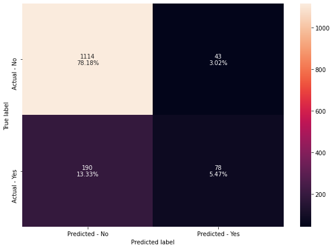

```python
make_confusion_matrix(adaboost_classifier, y_test)
```

Notes: Default AdaBoost looks to actually be worse than bagging. This chart shows 233 incorrect predictionn

```python
models.append(adaboost_classifier)
```

### GradientBoost

```python
gradientboost_classifier = GradientBoostingClassifier(random_state=1)
gradientboost_classifier.fit(X_train, y_train)
```

```
GradientBoostingClassifier(random_state=1)
```

```python
gradienboost_score = get_metrics_score(gradientboost_classifier)
```

```
Accuracy on training set :  0.8901264298615292
Accuracy on test set :  0.856140350877193
Recall on training set :  0.48562300319488816
Recall on test set :  0.3843283582089552
Precision on training set :  0.8760806916426513
Precision on test set :  0.7202797202797203
F1 score on training set :  0.6248715313463515
F1 score on test set :  0.5012165450121654
```

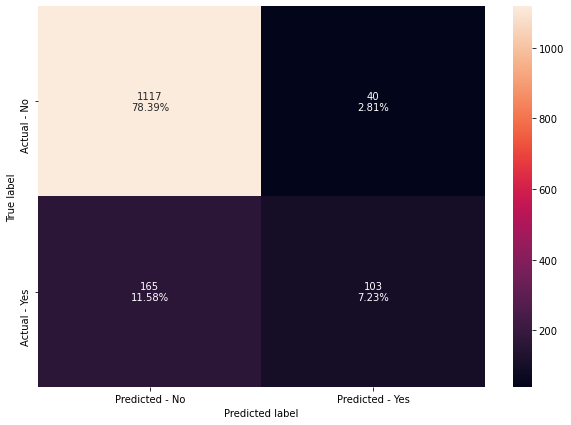

```python
make_confusion_matrix(gradientboost_classifier, y_test)
```

## Notes:

205 incorrect predictions when using default gradient boost settings

```python
models.append(gradientboost_classifier)
```

### XGBoost

```python
xgboost_classifier = XGBClassifier(random_state=1, eval_metric='logloss')
xgboost_classifier.fit(X_train, y_train)
```

```
XGBClassifier(base_score=0.5, booster='gbtree', colsample_bylevel=1,
              colsample_bynode=1, colsample_bytree=1, eval_metric='logloss',
              gamma=0, gpu_id=-1, importance_type='gain',
              interaction_constraints='', learning_rate=0.300000012,
              max_delta_step=0, max_depth=6, min_child_weight=1, missing=nan,
              monotone_constraints='()', n_estimators=100, n_jobs=0,
              num_parallel_tree=1, random_state=1, reg_alpha=0, reg_lambda=1,
              scale_pos_weight=1, subsample=1, tree_method='exact',
              validate_parameters=1, verbosity=None)
```

```python
xgboost_score = get_metrics_score(xgboost_classifier)
```

```
Accuracy on training set :  1.0
Accuracy on test set :  0.9221052631578948
Recall on training set :  1.0
Recall on test set :  0.7014925373134329
Precision on training set :  1.0
Precision on test set :  0.8584474885844748
F1 score on training set :  1.0
F1 score on test set :  0.7720739219712526
```

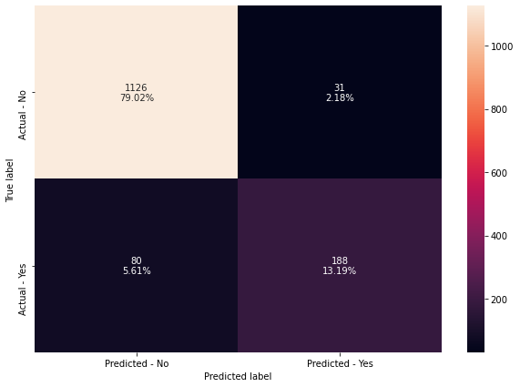

```python
make_confusion_matrix(xgboost_classifier, y_test)
```

## Notes:

Default XGBoost has only 111 incorrect predictions, the lowest of all the models so far

```python
models.append(xgboost_classifier)
```

## Boosting Performance Improvement with hyperparameters

Just as we can tune Bagging models with hyperparameters so to we can try to optimize Boosting models as well

### AdaBoost

```python
adaboost_tuned = AdaBoostClassifier(random_state=1)

parameters = {
    "base_estimator": [DecisionTreeClassifier(max_depth=1, random_state=1), DecisionTreeClassifier(max_depth=2, random_state=1), DecisionTreeClassifier(max_depth=3, random_state=1)],
    "n_estimators": np.arange(10, 110, 10),
    "learning_rate": np.arange(0.1, 2, 0.1)
}

acc_scorer = metrics.make_scorer(metrics.recall_score)

grid_obj = GridSearchCV(adaboost_tuned, parameters, scoring=acc_scorer, cv=5)
grid_obj = grid_obj.fit(X_train, y_train)

adaboost_tuned = grid_obj.best_estimator_

adaboost_tuned.fit(X_train, y_train)
```

```
AdaBoostClassifier(base_estimator=DecisionTreeClassifier(max_depth=3,
                                                         random_state=1),
                   learning_rate=1.5000000000000002, n_estimators=90,
                   random_state=1)
```

```python
adaboost_tuned_score = get_metrics_score(adaboost_tuned)
```

```
Accuracy on training set :  0.9876580373269115
Accuracy on test set :  0.8792982456140351
Recall on training set :  0.952076677316294
Recall on test set :  0.6044776119402985
Precision on training set :  0.9818780889621087
Precision on test set :  0.7105263157894737
F1 score on training set :  0.9667477696674777
F1 score on test set :  0.653225806451613
```

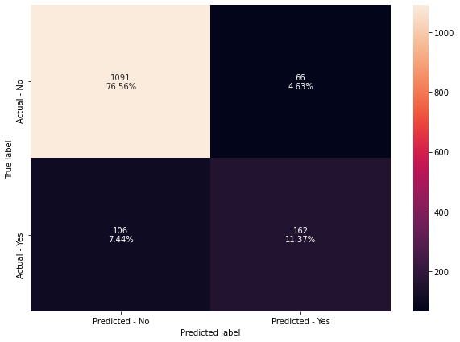

```python
make_confusion_matrix(adaboost_tuned, y_test)
```

## Notes:

with 172 incorrect predictions this model is not the worst, but still well off the results of the untuned XGBIISt

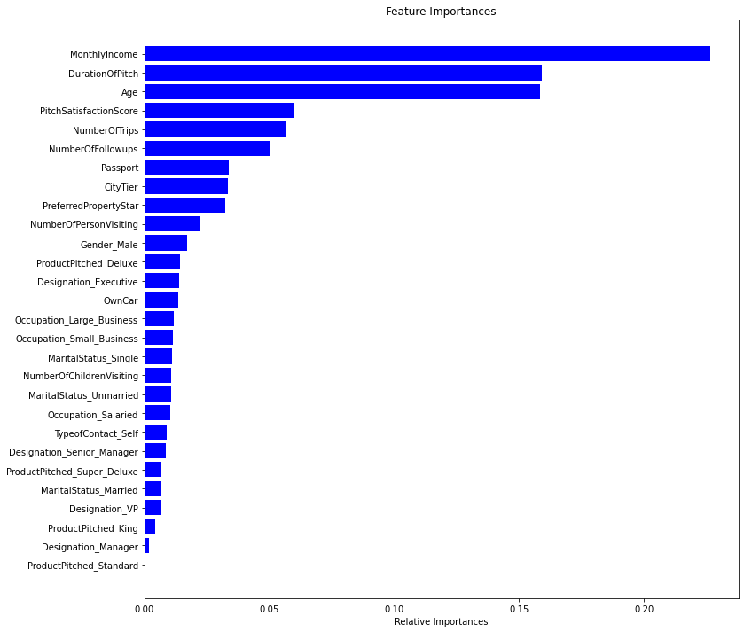

```python
importances = adaboost_tuned.feature_importances_
indices = np.argsort(importances)
feature_names = list(X.columns)

plt.figure(figsize=(12,12))
plt.title('Feature Importances')
plt.barh(range(len(indices)), importances[indices], color='blue', align='center')
plt.yticks(range(len(indices)), [feature_names[i] for i in indices])
plt.xlabel('Relative Importances')
plt.show();
```

```python
models.append(adaboost_tuned)
```

### GradientBoost using AdaBoost as the etimator

```python
gradient_boost_init = GradientBoostingClassifier(init=AdaBoostClassifier(random_state=1), random_state=1)
gradient_boost_init.fit(X_train, y_train)
```

```
GradientBoostingClassifier(init=AdaBoostClassifier(random_state=1),
                           random_state=1)
```

```python
gradient_boost_init_score = get_metrics_score(gradient_boost_init)
```

```
Accuracy on training set :  0.8871161950632149
Accuracy on test set :  0.863859649122807
Recall on training set :  0.46485623003194887
Recall on test set :  0.3843283582089552
Precision on training set :  0.879154078549849
Precision on test set :  0.7803030303030303
F1 score on training set :  0.6081504702194357
F1 score on test set :  0.515
```

```python
gradient_boost_tuned = GradientBoostingClassifier(init=AdaBoostClassifier(random_state=1), random_state=1)

parameters = {
    "n_estimators": [100, 150, 200, 250],
    "subsample": [0.8, 0.9, 1],
    "max_features": [0.7, 0.8, 0.9, 1]
}

acc_scorer = metrics.make_scorer(metrics.recall_score)

grid_obj = GridSearchCV(gradient_boost_tuned, parameters, scoring=acc_scorer, cv=5)
grid_obj = grid_obj.fit(X_train, y_train)

gradient_boost_tuned = grid_obj.best_estimator_

gradient_boost_tuned.fit(X_train, y_train)
```

```
GradientBoostingClassifier(init=AdaBoostClassifier(random_state=1),
                           max_features=0.7, n_estimators=250, random_state=1,
                           subsample=1)
```

```python
gradient_boost_tuned_score = get_metrics_score(gradient_boost_tuned)
```

```
Accuracy on training set :  0.9229379891631547
Accuracy on test set :  0.8680701754385964
Recall on training set :  0.6373801916932907
Recall on test set :  0.48880597014925375
Precision on training set :  0.9322429906542056
Precision on test set :  0.7197802197802198
F1 score on training set :  0.7571157495256168
F1 score on test set :  0.5822222222222223
```

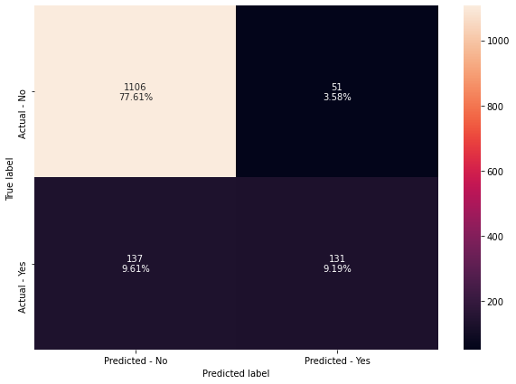

```python
make_confusion_matrix(gradient_boost_tuned, y_test)
```